# Datenanalyse von Einflussfaktoren im MBA-Zulassungsprozess

Sandro Kostenzer, Bryan Bernhauser und Illia Dollhov

2024-12-05

# Einleitung

Im Rahmen dieses Berichts erfolgt eine Analyse des Phänomens der Zulassung zu einem MBA-Programm. Hierbei wird ein besonderes Augenmerk auf die Faktoren gelegt, die die Entscheidung massgeblich beeinflussen könnten. Der zugrunde liegende Datensatz umfasst Informationen über Bewerberinnen und Bewerber, darunter GMAT-Ergebnisse, GPA-Werte (Grade Point Average), berufliche Erfahrung, Studiengänge, Ethnizität, Geschlecht sowie den Zulassungsstatus.

# Daten

## Herkunft des Datensatzes

Der Datensatz wurde von **Tawei Lo** auf der Plattform Kaggle bereitgestellt, welche sich auf Datenwissenschaft und maschinelles Lernen fokussiert. Der Datensatz beinhaltet Informationen zu MBA-Bewerbungen und zeichnet sich durch eine hohe Qualität sowie eine sorgfältige Auswahl der Daten aus, was ihn für Forscher und Praktiker gleichermassen von Nutzen macht.

## Zweck der Datenerfassung

Die Daten wurden mutmasslich mit dem Ziel gesammelt, Muster und Trends im Zulassungsprozess zu analysieren. Business Schools könnten derartige Datensätze nutzen, um ihren Entscheidungsprozess zu optimieren und Diversität sowie berufliche Erfahrungen in Einklang zu bringen.

## Variablen im Datensatz

Der Datensatz enthält die folgenden Variablen:

| **Variable** | **Beschreibung** | **Datentyp** |
| --- | --- | --- |
| `admission` | Gibt den Bewerbungsstatus der Bewerbung an: **zugelassen (Admit)**, **abgelehnt (Reject)** oder **Warteliste (Waitlist)** | Faktor |
| `gmat` | GMAT-Punktzahl des Bewerbers (numeric), eine standardisierte Bewertung für MBA-Zulassungen. | Numerisch |
| `gpa` | GPA (Grade Point Average) des Bewerbers im vorherigen Studium, ein Mass für akademische Leistung. | Numerisch |
| `work_exp` | Berufserfahrung in Jahren. | Numerisch |
| `major` | Studienfach des Bewerbers (z. B. Business, STEM, Humanities). | Faktor |
| `gender` | Geschlecht des Bewerbers (Male, Female). | Faktor |
| `race` | Ethnische Zugehörigkeit (z. B. Asian, White, African American, etc.). | Faktor |
| `work_industry` | Branche der bisherigen Berufserfahrung (z. B. Finance, Technology, Education). | Faktor |

## Bedeutung der Variablen

- **GMAT und GPA:** Wichtige akademische Kriterien zur Beurteilung der intellektuellen und akademischen Fähigkeiten des Bewerbers.
- **Work Experience:** Zeigt, wie viel Berufserfahrung die Bewerber mitbringen, ein bedeutender Faktor für MBA-Programme.
- **Major:** Repräsentiert den Studienhintergrund der Bewerber und kann Hinweise darauf geben, wie vielfältig ihre akademischen Hintergründe sind.
- **Gender, Race:** Bieten Einblicke in die Diversität der Bewerber und helfen, mögliche Muster in der Zulassung zu erkennen.
- **Work Industry:** Zeigt die beruflichen Branchen, in denen die Bewerber bisher tätig waren, und gibt Aufschluss über Karrieretypen.

## Datenpunkte

Der Datensatz umfasst insgesamt **6149 Datenpunkte**, wobei jeder Datenpunkt einem Bewerber entspricht und Informationen zu den zuvor genannten Variablen beinhaltet.

# Exploration

## Univariate Analysen

### **Verteilung der GMAT-Punktzahlen**

Die erste Grafik präsentiert ein Histogramm der GMAT-Punktzahlen aller Bewerberinnen und Bewerber. Die GMAT-Werte sind in Intervallen von 10 zusammengefasst, wobei der Anfangspunkt bei 560 liegt. Die $x$-Achse zeigt die GMAT-Punktzahl, während die $y$-Achse die Anzahl der Bewerberinnen und Bewerber in jeder Punktzahlklasse darstellt.

**Beobachtungen:**

- Die GMAT-Punktzahlen der Bewerber sind leicht rechtsschief und bimodal.
- Der häufigste Bereich liegt zwischen **570 und 580**.
- Punktzahlen über 720 sind weniger häufig vertreten.

**Interpretation:**  
Die GMAT-Verteilung spiegelt die akademische Kompetenz der Bewerber wider. Ein grosser Anteil erreicht Punktzahlen, die typischerweise als wettbewerbsfähig für MBA-Zulassungen gelten. Bewerber mit sehr hohen Punktzahlen stellen eine kleinere Gruppe dar, was auf die Selektivität und den Schwierigkeitsgrad des Tests hinweist.

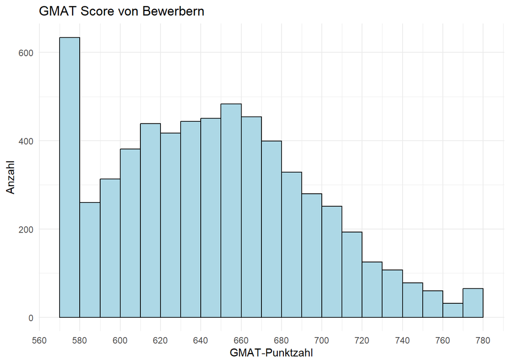

```r
ggplot(data, aes(x=gmat))+
  geom_histogram(color='black', fill='lightblue', binwidth = 10,boundary = 560)+
  scale_x_continuous(breaks = seq(540,800, by = 20))+
  theme_minimal() +
  labs(title = "GMAT Score von Bewerbern", y='Anzahl', x='GMAT-Punktzahl')
```

### **Prozentuale Verteilung der ethnischer Zugehörigkeit**

Die zweite Grafik präsentiert ein Kreisdiagramm, welches die prozentuale Verteilung der Bewerberinnen und Bewerber nach ethnischer Zugehörigkeit darstellt. Die Anteile der einzelnen Gruppen sind farblich unterschiedlich visualisiert, wobei eine Legende zur Identifikation bereitgestellt wird.

**Beobachtungen:**

- **Weisse Bewerber** bilden mit **33,5 %** die grösste Gruppe, gefolgt von **Asiatischen Bewerbern** mit **26,4 %**.
- **Schwarze Bewerber** machen **21 %**, **Hispanische Bewerber** **13,7 %** und **Andere Bewerber** nur **5,4 %** aus.

**Interpretation:**  
Die Daten zeigen eine gewisse Diversität, jedoch dominieren “White” und “Asian”. Unterrepräsentierte Gruppen wie “Hispanic” und “Other” dies könnte auf Barrieren im Zugang oder auf regionale Unterschiede hinweisen.

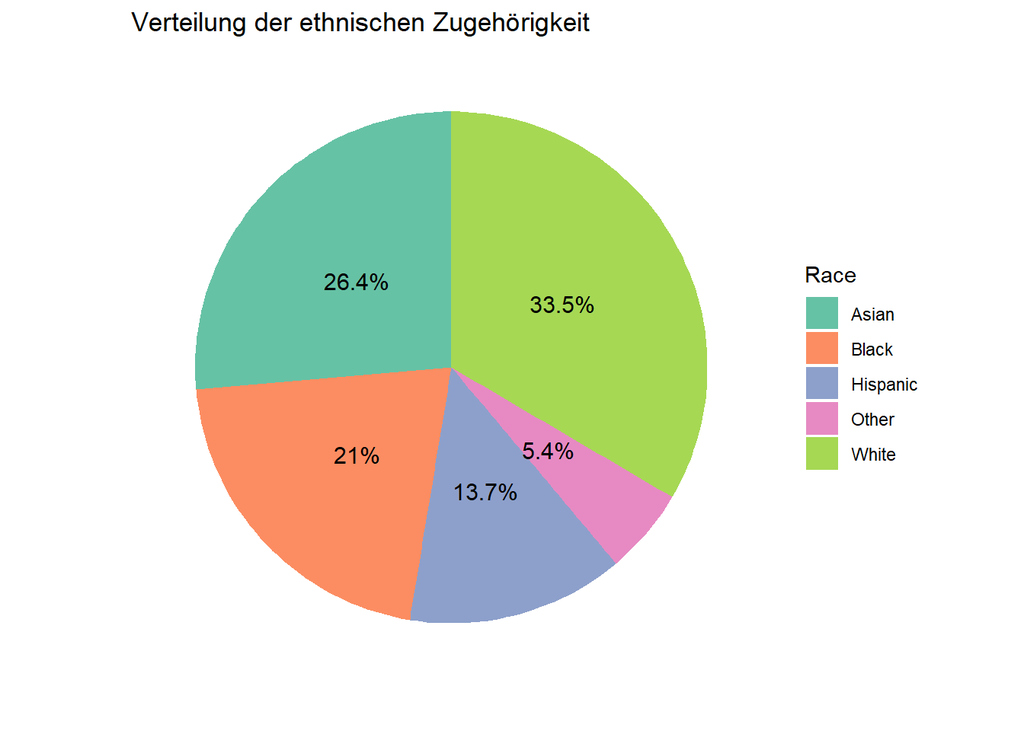

```r
races <- data$race[!is.na(data$race) & data$race != ""]
race_counts <- table(races) %>%
  as.data.frame() %>%
  rename(Race = races, Count = Freq) %>%
  mutate(Percentage = Count / sum(Count) * 100)

ggplot(race_counts, aes(x = "", y = Count, fill = Race)) +
  geom_bar(stat = "identity", width = 1)+
  geom_text(aes(label = paste0(round(Percentage, 1), "%")),
            position = position_stack(vjust = 0.5), size = 4) +
  coord_polar(theta = "y") +
  theme_minimal()+
  theme(axis.text.x = element_blank(),
        axis.ticks = element_blank(),
        panel.grid = element_blank()) +
  labs(title = "Verteilung der ethnischen Zugehörigkeit", fill = "Race", x="", y ="") +
  scale_fill_brewer(palette = "Set2")
```

## Bi- und multivariate Analysen

### **Verteilung der Berufserfahrung in Abhängigkeit vom Zulassungsstatus**

Die Violin-Grafik zeigt die Verteilung der **Berufserfahrung** für jeden **Zulassungsstatus**

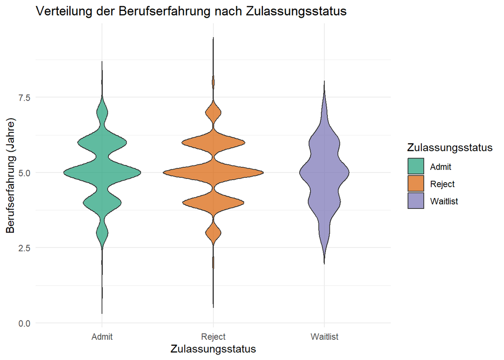

```r
ggplot(data, aes(x = admission, y = work_exp, fill = admission)) +
  geom_violin(alpha = 0.7, trim = FALSE) +
  scale_fill_manual(
    values = c("Admit" = "#1b9e77", "Reject" = "#d95f02", "Waitlist" = "#7570b3")
  ) +
  labs(
    title = "Verteilung der Berufserfahrung nach Zulassungsstatus",
    x = "Zulassungsstatus",
    y = "Berufserfahrung (Jahre)",
    fill = "Zulassungsstatus"
  ) +
  theme_minimal()
```

### **Verteilung der Berufserfahrung nach Studiengang**

Die Histogramm-Grafik zeigt die Verteilung der **Berufserfahrung**, aufgeteilt nach den **Studiengängen**

#### **Beobachtungen:**

1. **Gesamte Verteilung:**
   - Die Berufserfahrung konzentriert sich bei allen Studiengängen im Bereich von **3 bis 6 Jahren**.
   - Die Verteilung folgt bei allen Gruppen einer glockenförmigen Kurve, was auf eine Normalverteilung hinweist.
2. **Studiengangsabhängige Unterschiede:**
   - Bewerber auf einen **Humanities** Studiengang stellen die grösste Gruppe.
   - Bewerber aus **Business** und **STEM** haben eine ähnliche Verteilung.

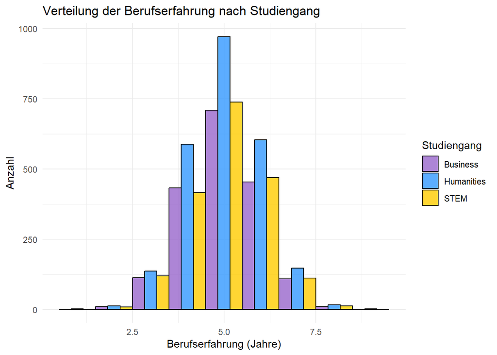

```r
ggplot(data, aes(x = work_exp, fill = major)) +
  geom_histogram(binwidth = 1, position = "dodge", alpha = 0.8, color = "black") +
  scale_fill_manual(
    values = c("STEM" = "#ffcc00", "Humanities" = "#3399ff", "Business" = "#9966cc")
  ) +
  labs(
    title = "Verteilung der Berufserfahrung nach Studiengang",
    x = "Berufserfahrung (Jahre)",
    y = "Anzahl",
    fill = "Studiengang"
  ) +
  theme_minimal()
```

#### **Zusammenhang zwischen GMAT, GPA und Zulassungsstatus der Bewerber**

Die dargestellte Grafik zeigt die Beziehung zwischen GMAT-Punktzahl, GPA und Zulassungsstatus

#### **Beobachtungen**

1. **GMAT und GPA:**
   - Höhere GMAT-Punktzahlen scheinen mit einem höheren GPA verbunden zu sein.
   - Bewerber mit niedrigen GMAT- und GPA-Werten werden meist abgelehnt.
2. **Zulassungsstatus:**
   - **Zulassungen (grüne Punkte)** konzentrieren sich auf Bewerber mit höheren GMAT-Punktzahlen (über 660) und GPAs (über 3.2).
   - **Wartelisten-Bewerber (lila Punkte)** liegen tendenziell zwischen den Extremen, jedoch näher an den abgelehnten Bewerbern.
   - **Abgelehnte Bewerber (orange Punkte)** sind stark im unteren Bereich der GMAT- und GPA-Werte vertreten.

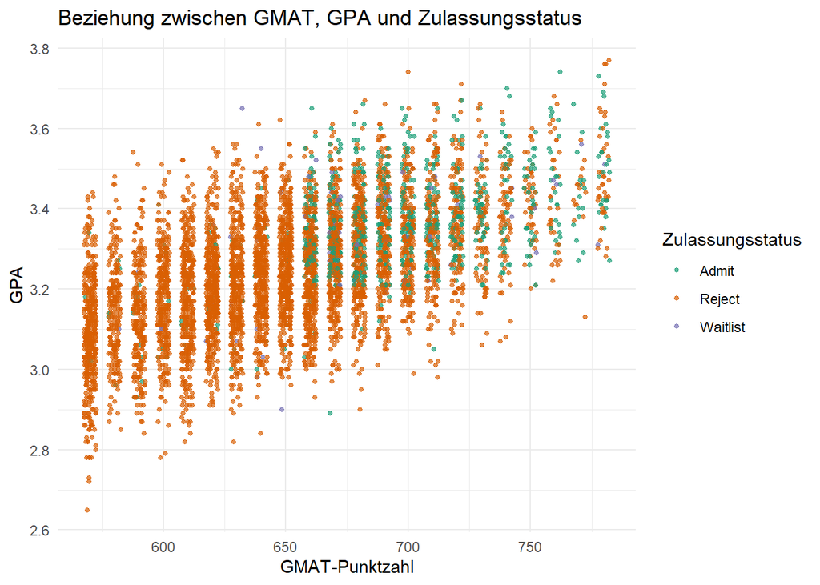

```r
ggplot(data, aes(x = gmat, y = gpa, color = admission)) +
  geom_jitter(alpha = 0.7, height = 0, width = 2.5, size = 1) +
  scale_color_manual(
    values = c("Admit" = "#1b9e77", "Reject" = "#d95f02", "Waitlist" = "#7570b3")
  ) +
  labs(
    title = "Beziehung zwischen GMAT, GPA und Zulassungsstatus",
    x = "GMAT-Punktzahl",
    y = "GPA",
    color = "Zulassungsstatus"
  ) +
  theme_minimal()
```

### **Einfluss von Branche, Berufserfahrung und Studiengang auf den Zulassungsstatus**

Die dargestellte Grafik untersucht die **Berufserfahrung** der Bewerber in verschiedenen Branchen, unterteilt nach **Zulassungsstatus** und **Studiengang**.

#### **Interpretation**

Die Analyse zeigt, dass sowohl die Branche als auch der Studiengang die Bedeutung der Berufserfahrung für die Zulassung beeinflussen. Bewerber aus wettbewerbsintensiven Branchen wie Investment Banking oder Technology mit mehr Berufserfahrung haben bessere Chancen auf eine Zulassung.

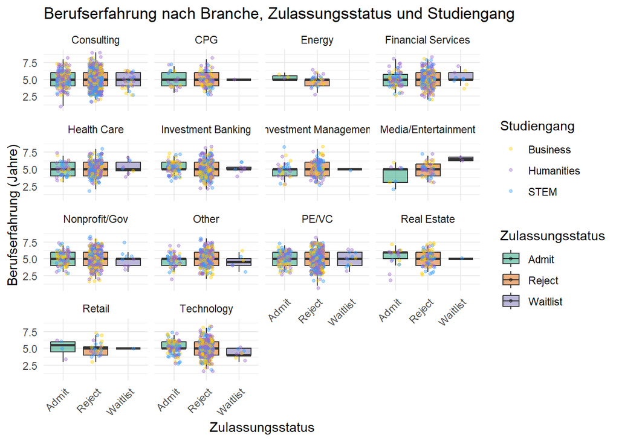

```r
ggplot(data, aes(x = admission, y = work_exp, fill = admission)) +
  geom_boxplot(alpha = 0.5, outlier.shape = NA) +
  geom_jitter(aes(color = major), alpha = 0.4, width = 0.2, size = 1) +
  scale_fill_manual(
    values = c("Admit" = "#1b9e77", "Reject" = "#d95f02", "Waitlist" = "#7570b3")
  ) +
  scale_color_manual(
    values = c("Business" = "#ffcc00", "Humanities" = "#9966cc", "STEM" = "#3399ff")
  ) +
  facet_wrap(~work_industry) +
  labs(
    title = "Berufserfahrung nach Branche, Zulassungsstatus und Studiengang",
    x = "Zulassungsstatus",
    y = "Berufserfahrung (Jahre)",
    fill = "Zulassungsstatus",
    color = "Studiengang"
  ) +
  theme_minimal() +
  theme(axis.text.x = element_text(angle = 45, hjust = 1))
```

# Zusammenfassung